# Analysing and visualising rating scales in R using ratingScaleSummary

Till Krenz

2017-01-19

# ratingScaleSummary

This package is supposed to give a fast and useful summary and visualisation of a rating scale, consisting of several variables using the same categories/ codings. These procedures might be useful for social scientists and psychologists and everyone else working with data collected via surveys making use of the the concept of multiple indicators for the measurment of dimensions of abstract or complex social concepts and terms.

In addition there are functions for calculating the interpolated median and percentiles of a grouped frequency distribution, the inter quartile range, and relative frequency and cross tables. The latter functions produce data frames, the output is therefore modified and reused much easier, than the outputs created by, e.g. the functions of the package ‘descr’. The functions in this package produce output that is supposed to be easily integrated into RMarkdown and knitr files.

# Install Package

For now the ratingSclaeSummary package is not available on CRAN, but it can be installed driectly from github from within R using the devtools package

```
devtools::install_github('ratingScaleSummary/tilltnet')
```

or by using the source package for a local install.

# Let’s get started: creating sample data

We start with creating some sample data, that will be used throughout this vignette. We’ll need a *data.frame* consisting of several variables, all using the same categories. In addition we create a grouping variable, that is used for the examples that incorporate group comparisson.

```r
df <- data.frame(replicate(6,sample(as.character(1:7), 2000, replace = T, prob = sample(1:100/100, 7))))
var_names <- lapply(1:6, FUN = function(x) paste(sample(letters, sample(6:13, 1)), collapse = ""))
names(df) <- var_names

g <- sample(c("G1", "G2", "G3"), 2000, replace = T)
```

# Summarise a rating scale

rs_summary() returns a **data.frame** where each row represents one variable. It provides categories’ frequencies (in %), N, median, and the interquartile range.

```r
library(ratingScaleSummary)
res <- rs_summary(df = df)
knitr::kable(res)
```

|  | 1 | 2 | 3 | 4 | 5 | 6 | 7 | N | Median | intQR | NA |
| --- | --- | --- | --- | --- | --- | --- | --- | --- | --- | --- | --- |
| gzapfinjstoy | 2.8 | 31.2 | 19.4 | 1.7 | 22.8 | 4.4 | 17.7 | 2000 | 3.322 | 3.163 | 0 |
| jnrabgvohd | 19.2 | 8.5 | 20.0 | 15.9 | 13.4 | 2.2 | 20.8 | 2000 | 3.645 | 3.178 | 0 |
| pkbuxseg | 26.5 | 5.1 | 14.0 | 18.2 | 6.0 | 27.2 | 3.1 | 2000 | 3.747 | 4.250 | 0 |
| vwdqzx | 17.6 | 18.6 | 9.0 | 11.2 | 7.5 | 19.5 | 16.5 | 2000 | 3.922 | 4.168 | 0 |
| peftzniugaks | 18.3 | 10.5 | 13.3 | 11.9 | 13.7 | 16.7 | 15.6 | 2000 | 4.157 | 3.797 | 0 |
| fyxazjcotukdq | 1.9 | 12.1 | 3.1 | 16.4 | 25.5 | 22.8 | 18.3 | 2000 | 5.149 | 2.222 | 0 |

## Visualise medians of a rating scale

vert_line_base() and vert_line_gg() plots a vertical line dot plot using base plotting or ggplot2.

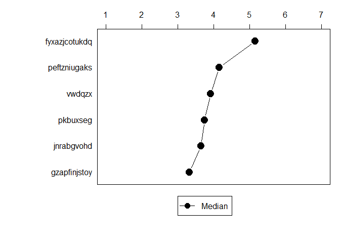

```r
# Using base plot.
vert_line_base(x = res["Median"], max_val = 7)
```

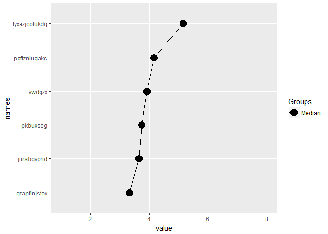

```r
# Using ggplot2.
vert_line_gg(x = res["Median"], max_val = 7)
```

# Compare the responses to a rating scale by groups

Returns a **data.frame** where each row represents one variable and the columns show the median values of the comparison groups. An additional colum shows the significance levels, based on the **Kruskal-Wallis** **Rank** **Sum** **Test**.

```r
# Compare medians between groups accross several variables.
res_comp <- rs_compare_groups(df = df, groups = g)
knitr::kable(res_comp)
```

|  | G1 | G2 | G3 | sig |
| --- | --- | --- | --- | --- |
| gzapfinjstoy | 3.308 | 3.235 | 3.426 | n.s. |
| jnrabgvohd | 3.530 | 3.726 | 3.671 | n.s. |
| pkbuxseg | 3.801 | 3.648 | 3.789 | n.s. |
| vwdqzx | 3.803 | 4.021 | 3.949 | n.s. |
| peftzniugaks | 4.250 | 4.176 | 4.046 | n.s. |
| fyxazjcotukdq | 5.169 | 5.160 | 5.117 | n.s. |

## Visualise the comparisson

vert_line_base() and vert_line_gg() also produce plots for group comparisson.

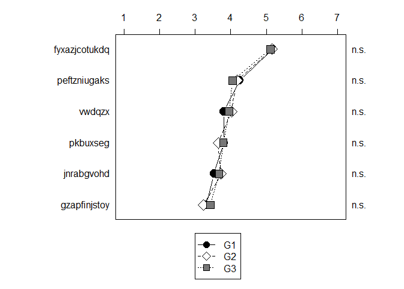

```r
# Using base plot.
vert_line_base(x = res_comp, max_val = 7)
```

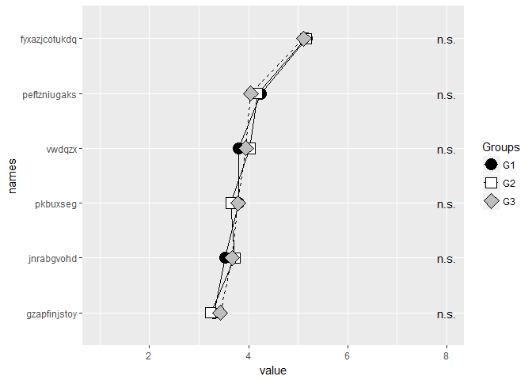

```r
# Using ggplot2.
vert_line_gg(x = res_comp, max_val = 7)
```

# Using ggplot2 theming

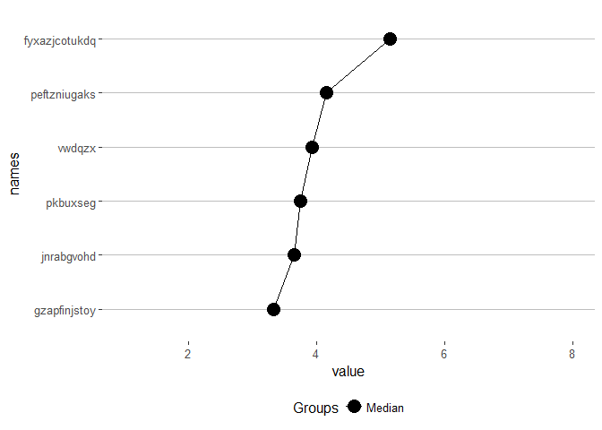

```r
library(ggthemes)
vert_line_gg(x = res["Median"], max_val = 7) +  theme_hc()
```

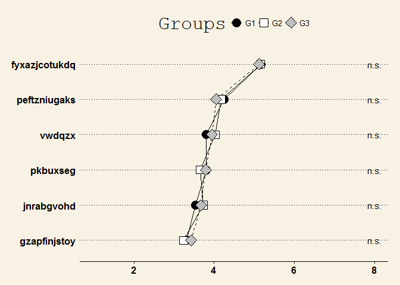

```r
vert_line_gg(x = res_comp, max_val = 7) + theme_wsj()
```

# Miscellaneous functions within the package